# Loan Data Analysis & Modeling

A Teaching Guide for R Beginners in RStudio

Valerie Jerono

2026-04-14

> **Before you start:** Open this file in RStudio. You can run each code chunk  
> by clicking the green ▶ button on its top-right, or press **Ctrl+Shift+Enter**  
> (Windows/Linux) / **Cmd+Shift+Enter** (Mac). To produce the full HTML report,  
> click **Knit** in the toolbar at the top.

## 1 · Setup: Installing & Loading Packages

> **📘 What is a package?**  
> R’s base installation is powerful, but the R community has written thousands of  
> *packages* (add-ons) that extend it. You install a package once with  
> `install.packages()`, then load it each session with `library()`.

> Think of it like: installing an app on your phone (once) vs. opening it (every time).

```r
# Run this block ONCE to install all required packages.
# After installation, you never need to run install.packages() again
# for these packages on your computer.

install.packages(c(
  "tidyverse",  # Collection of data science tools (ggplot2, dplyr, tidyr, etc.)
  "caret",      # Classification And REgression Training — machine learning toolkit
  "corrplot",   # Visualising correlation matrices
  "car",        # Companion to Applied Regression (includes VIF function)
  "MASS",       # Modern Applied Statistics (includes stepAIC)
  "ROCR"        # ROC curves for classifier evaluation
))
```

```r
# Load packages every time you open a new R session.
# library() makes the package's functions available in your environment.

library(tidyverse)  # loads ggplot2, dplyr, tidyr, readr, and more
library(caret)
library(corrplot)
library(car)
library(MASS)
library(ROCR)
library(dplyr)      # loaded by tidyverse, but we call it explicitly for clarity
```

> **📘 Why does tidyverse load so many things?**  
> `tidyverse` is a “meta-package” — a curated collection. When you run  
> `library(tidyverse)`, it silently loads ~8 packages at once, saving you time.

## 2 · Load & Explore the Dataset

> **📘 Assigning variables with `<-`**  
> In R, the assignment operator is `<-` (not `=`). It means “store the result  
> on the right into the name on the left”. You can read `data <- read.csv(...)` as  
> *“data gets the CSV file”*. Keyboard shortcut: **Alt + –** (Windows) / **Option + –** (Mac).

```r
# Read the CSV file into a data frame called 'data'.
# A data frame is R's version of a spreadsheet/table — rows are observations,
# columns are variables.

# ⚠️  Update this path to wherever your loan_data.csv is saved on YOUR computer.
# Example on Windows: "C:/Users/YourName/Downloads/loan_data.csv"
# Example on Mac:     "/Users/YourName/Downloads/loan_data.csv"

data <- read.csv("loan_data.csv")

# head() shows the first 6 rows — a quick peek at the structure
head(data)
```

```
##   person_age person_gender person_education person_income person_emp_exp
## 1         22        female           Master         71948              0
## 2         21        female      High School         12282              0
## 3         25        female      High School         12438              3
## 4         23        female         Bachelor         79753              0
## 5         24          male           Master         66135              1
## 6         21        female      High School         12951              0
##   person_home_ownership loan_amnt loan_intent loan_int_rate loan_percent_income
## 1                  RENT     35000    PERSONAL         16.02                0.49
## 2                   OWN      1000   EDUCATION         11.14                0.08
## 3              MORTGAGE      5500     MEDICAL         12.87                0.44
## 4                  RENT     35000     MEDICAL         15.23                0.44
## 5                  RENT     35000     MEDICAL         14.27                0.53
## 6                   OWN      2500     VENTURE          7.14                0.19
##   cb_person_cred_hist_length credit_score previous_loan_defaults_on_file
## 1                          3          561                             No
## 2                          2          504                            Yes
## 3                          3          635                             No
## 4                          2          675                             No
## 5                          4          586                             No
## 6                          2          532                             No
##   loan_status
## 1           1
## 2           0
## 3           1
## 4           1
## 5           1
## 6           1
```

```r
# summary() gives descriptive statistics for every column:
#   - For numeric columns: min, max, mean, median, quartiles
#   - For character/factor columns: frequency counts

summary(data)
```

```
##    person_age     person_gender      person_education   person_income
##  Min.   : 20.00   Length:45000       Length:45000       Min.   :   8000
##  1st Qu.: 24.00   Class :character   Class :character   1st Qu.:  47204
##  Median : 26.00   Mode  :character   Mode  :character   Median :  67048
##  Mean   : 27.76                                         Mean   :  80319
##  3rd Qu.: 30.00                                         3rd Qu.:  95789
##  Max.   :144.00                                         Max.   :7200766
##  person_emp_exp   person_home_ownership   loan_amnt     loan_intent
##  Min.   :  0.00   Length:45000          Min.   :  500   Length:45000
##  1st Qu.:  1.00   Class :character      1st Qu.: 5000   Class :character
##  Median :  4.00   Mode  :character      Median : 8000   Mode  :character
##  Mean   :  5.41                         Mean   : 9583
##  3rd Qu.:  8.00                         3rd Qu.:12237
##  Max.   :125.00                         Max.   :35000
##  loan_int_rate   loan_percent_income cb_person_cred_hist_length  credit_score
##  Min.   : 5.42   Min.   :0.0000      Min.   : 2.000             Min.   :390.0
##  1st Qu.: 8.59   1st Qu.:0.0700      1st Qu.: 3.000             1st Qu.:601.0
##  Median :11.01   Median :0.1200      Median : 4.000             Median :640.0
##  Mean   :11.01   Mean   :0.1397      Mean   : 5.867             Mean   :632.6
##  3rd Qu.:12.99   3rd Qu.:0.1900      3rd Qu.: 8.000             3rd Qu.:670.0
##  Max.   :20.00   Max.   :0.6600      Max.   :30.000             Max.   :850.0
##  previous_loan_defaults_on_file  loan_status
##  Length:45000                   Min.   :0.0000
##  Class :character               1st Qu.:0.0000
##  Mode  :character               Median :0.0000
##                                 Mean   :0.2222
##                                 3rd Qu.:0.0000
##                                 Max.   :1.0000
```

> **📘 Reading the summary output**  
> - **Min / Max**: the smallest and largest values in that column  
> - **Mean**: the average (sum divided by count)  
> - **Median**: the middle value when sorted — less sensitive to outliers than mean  
> - **1st Qu. / 3rd Qu.**: the 25th and 75th percentile values

> When Mean >> Median, the data is *right-skewed* (a few very large values pull  
> the mean up). This is common for income data, which we will address later.

## 3 · Data Cleaning

### 3.1 Check for Missing Values

> **📘 `colSums(is.na(...))`**  
> - `is.na(data)` produces a TRUE/FALSE table — TRUE wherever a value is missing  
> - `colSums(...)` sums each column (TRUE = 1, FALSE = 0)  
> - Result: count of missing values per column

```r
# Count missing values in each column.
# A result of 0 for every column means the data is complete — no gaps to fill.
colSums(is.na(data))
```

```
##                     person_age                  person_gender
##                              0                              0
##               person_education                  person_income
##                              0                              0
##                 person_emp_exp          person_home_ownership
##                              0                              0
##                      loan_amnt                    loan_intent
##                              0                              0
##                  loan_int_rate            loan_percent_income
##                              0                              0
##     cb_person_cred_hist_length                   credit_score
##                              0                              0
## previous_loan_defaults_on_file                    loan_status
##                              0                              0
```

### 3.2 Convert Categorical Columns to Factors

> **📘 What is a `factor`?**  
> R has a special data type for *categorical* variables called a **factor**.  
> A factor stores distinct categories (called *levels*) and encodes them  
> internally as integers. This matters for modelling — when R sees a factor,  
> it knows to create *dummy variables* automatically (more on this soon).

> Without conversion, R would treat a column like `person_gender` as plain text  
> and most modelling functions would either error or ignore it.

```r
# Convert each categorical column from character to factor.
# Syntax: data$column_name  accesses a single column from a data frame.

data$person_gender              <- as.factor(data$person_gender)
data$person_education           <- as.factor(data$person_education)
data$person_home_ownership      <- as.factor(data$person_home_ownership)
data$loan_intent                <- as.factor(data$loan_intent)
data$previous_loan_defaults_on_file <- as.factor(data$previous_loan_defaults_on_file)

# loan_status is our classification target: 0 = did not default, 1 = defaulted
data$loan_status                <- as.factor(data$loan_status)

# Verify the changes — factor columns now show levels instead of raw text
summary(data)
```

```
##    person_age     person_gender     person_education person_income
##  Min.   : 20.00   female:20159   Associate  :12028   Min.   :   8000
##  1st Qu.: 24.00   male  :24841   Bachelor   :13399   1st Qu.:  47204
##  Median : 26.00                  Doctorate  :  621   Median :  67048
##  Mean   : 27.76                  High School:11972   Mean   :  80319
##  3rd Qu.: 30.00                  Master     : 6980   3rd Qu.:  95789
##  Max.   :144.00                                      Max.   :7200766
##  person_emp_exp   person_home_ownership   loan_amnt
##  Min.   :  0.00   MORTGAGE:18489        Min.   :  500
##  1st Qu.:  1.00   OTHER   :  117        1st Qu.: 5000
##  Median :  4.00   OWN     : 2951        Median : 8000
##  Mean   :  5.41   RENT    :23443        Mean   : 9583
##  3rd Qu.:  8.00                         3rd Qu.:12237
##  Max.   :125.00                         Max.   :35000
##             loan_intent   loan_int_rate   loan_percent_income
##  DEBTCONSOLIDATION:7145   Min.   : 5.42   Min.   :0.0000
##  EDUCATION        :9153   1st Qu.: 8.59   1st Qu.:0.0700
##  HOMEIMPROVEMENT  :4783   Median :11.01   Median :0.1200
##  MEDICAL          :8548   Mean   :11.01   Mean   :0.1397
##  PERSONAL         :7552   3rd Qu.:12.99   3rd Qu.:0.1900
##  VENTURE          :7819   Max.   :20.00   Max.   :0.6600
##  cb_person_cred_hist_length  credit_score   previous_loan_defaults_on_file
##  Min.   : 2.000             Min.   :390.0   No :22142
##  1st Qu.: 3.000             1st Qu.:601.0   Yes:22858
##  Median : 4.000             Median :640.0
##  Mean   : 5.867             Mean   :632.6
##  3rd Qu.: 8.000             3rd Qu.:670.0
##  Max.   :30.000             Max.   :850.0
##  loan_status
##  0:35000
##  1:10000
##
##
##
##
```

## 4 · Exploratory Data Analysis (EDA)

### 4.1 Correlation Matrix

> **📘 What is correlation?**  
> Correlation measures the *linear* relationship between two numeric variables.  
> - **+1**: perfect positive relationship (as X increases, Y increases)  
> - **-1**: perfect negative relationship (as X increases, Y decreases)  
> - **0**: no linear relationship

> **Why does it matter?** Highly correlated *predictor* variables (correlation > 0.8)  
> can cause *multicollinearity* in regression models — we will check for this later.

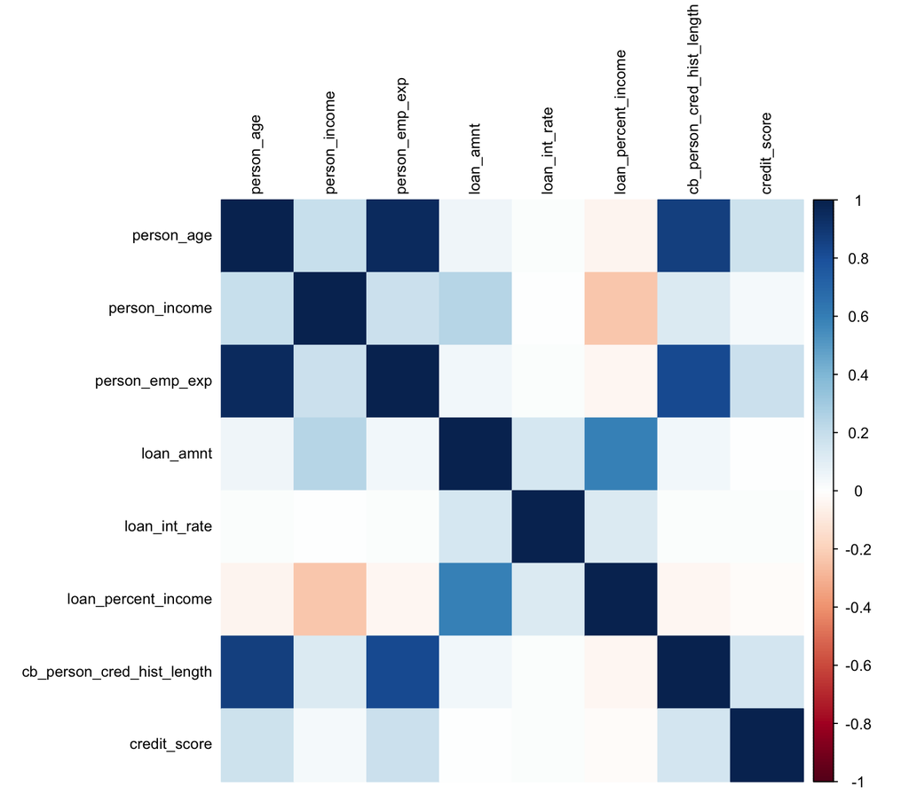

```r
# Step 1: Keep only numeric columns — cor() can't handle factors or text.
# The pipe operator %>% means "take the result and pass it to the next function".
# dplyr::select() specifies we want select() from dplyr (avoids name conflicts).
# where(is.numeric) is a helper that picks columns satisfying is.numeric.

numeric_data <- data %>% dplyr::select(where(is.numeric))

# Step 2: Compute the correlation matrix
cor_matrix <- cor(numeric_data)

# Step 3: Visualise with corrplot
# method = "color" fills each cell with a colour proportional to the correlation.
# Blue = positive correlation, Red = negative correlation.
corrplot(cor_matrix, method = "color",
         tl.cex = 0.8,    # text label size
         tl.col = "black") # text label colour
```

### 4.2 Income Distribution

> **📘 `hist()` — Histogram**  
> A histogram splits a numeric variable into equal-width *bins* and counts how  
> many observations fall into each bin. It reveals the *shape* of the distribution.

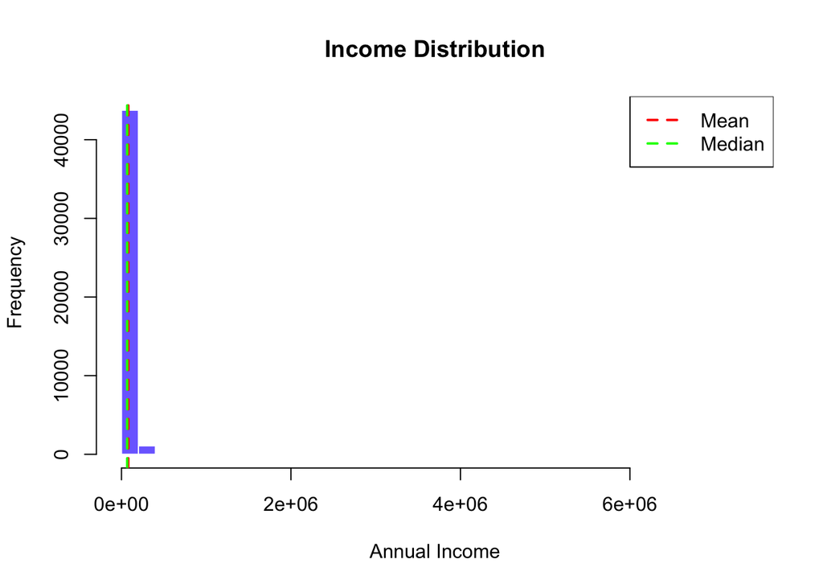

```r
hist(data$person_income,
     breaks = 30,                  # number of bins
     main   = "Income Distribution",
     xlab   = "Annual Income",
     col    = "#7c6fff",
     border = "white")

# Add a vertical line at the mean and median to see the skew
abline(v = mean(data$person_income),   col = "red",   lwd = 2, lty = 2)
abline(v = median(data$person_income), col = "green", lwd = 2, lty = 2)
legend("topright",
       legend = c("Mean", "Median"),
       col    = c("red", "green"),
       lty    = 2, lwd = 2)
```

> **🔍 Interpretation:**  
> The distribution is **right-skewed** — most people earn low-to-moderate income,  
> with a long tail of high earners. The mean is pulled right of the median.

> **Why this matters:** Linear regression assumes residuals are normally distributed.  
> A skewed *target variable* often violates this. The fix: **log transformation**.

## 5 · Linear Regression — Predicting Income

> **📘 What is linear regression?**  
> Linear regression fits a straight-line relationship between a target variable Y  
> (what we want to predict) and one or more predictor variables X:

> `Y = β₀ + β₁X₁ + β₂X₂ + ... + ε`

> The model *learns* the β coefficients (slopes) that minimise prediction error.  
> In R, you describe this relationship with a **formula**: `target ~ predictors`.  
> Using `.` as the predictor means “use all other columns”.

### 5.1 Train/Test Split

> **📘 Why split the data?**  
> We train the model on one portion of data and evaluate it on an *unseen* portion.  
> This tests whether the model *generalises* rather than just memorising training data  
> (a problem called *overfitting*).

```r
set.seed(123)
# set.seed() ensures randomness is reproducible — run this code on any computer
# and you'll get the same split. The number 123 is arbitrary; any integer works.

# createDataPartition() from caret splits indices proportionally.
# p = 0.8 means 80% goes to training.
# list = FALSE returns a plain vector of row numbers, not a list.
train_index <- createDataPartition(data$person_income, p = 0.8, list = FALSE)

# Subset the data using the indices:
# data[train_index, ]  — rows in train_index,  all columns
# data[-train_index, ] — rows NOT in train_index (the minus sign = "exclude")
train <- data[train_index, ]
test  <- data[-train_index, ]

cat("Training rows:", nrow(train), "\n")
```

```
## Training rows: 36001
```

```r
cat("Test rows    :", nrow(test),  "\n")
```

```
## Test rows    : 8999
```

### 5.2 Fit Baseline Linear Model

```r
# lm() = linear model
# Formula: person_income ~ .  means: predict income using ALL other columns
# data = train: fit on training data only

lm_model <- lm(person_income ~ ., data = train)

summary(lm_model)
```

```
##
## Call:
## lm(formula = person_income ~ ., data = train)
##
## Residuals:
##     Min      1Q  Median      3Q     Max
## -430020  -17797   -4787    9039 6657131
##
## Coefficients:
##                                     Estimate Std. Error t value Pr(>|t|)
## (Intercept)                        1.592e+04  7.354e+03   2.164 0.030452 *
## person_age                         3.545e+03  2.298e+02  15.427  < 2e-16 ***
## person_gendermale                  1.920e+02  7.476e+02   0.257 0.797336
## person_educationBachelor           5.807e+02  9.961e+02   0.583 0.559875
## person_educationDoctorate         -3.577e+03  3.276e+03  -1.092 0.274982
## person_educationHigh School       -3.394e+02  1.020e+03  -0.333 0.739202
## person_educationMaster             2.067e+02  1.200e+03   0.172 0.863282
## person_emp_exp                     6.803e+02  2.057e+02   3.308 0.000940 ***
## person_home_ownershipOTHER         6.883e+03  7.382e+03   0.932 0.351159
## person_home_ownershipOWN          -2.018e+03  1.622e+03  -1.245 0.213319
## person_home_ownershipRENT         -9.111e+03  8.386e+02 -10.865  < 2e-16 ***
## loan_amnt                          7.120e+00  7.890e-02  90.247  < 2e-16 ***
## loan_intentEDUCATION               1.056e+03  1.253e+03   0.843 0.399438
## loan_intentHOMEIMPROVEMENT        -1.806e+03  1.483e+03  -1.217 0.223482
## loan_intentMEDICAL                -1.541e+03  1.269e+03  -1.214 0.224750
## loan_intentPERSONAL                2.332e+03  1.306e+03   1.785 0.074246 .
## loan_intentVENTURE                 3.132e+03  1.309e+03   2.392 0.016755 *
## loan_int_rate                     -5.067e+02  1.347e+02  -3.761 0.000169 ***
## loan_percent_income               -5.253e+05  6.046e+03 -86.896  < 2e-16 ***
## cb_person_cred_hist_length        -3.826e+03  1.861e+02 -20.562  < 2e-16 ***
## credit_score                      -3.432e+00  7.855e+00  -0.437 0.662185
## previous_loan_defaults_on_fileYes -5.759e+02  9.083e+02  -0.634 0.526041
## loan_status1                       9.578e+03  1.226e+03   7.815 5.64e-15 ***
## ---
## Signif. codes:  0 '***' 0.001 '**' 0.01 '*' 0.05 '.' 0.1 ' ' 1
##
## Residual standard error: 70520 on 35978 degrees of freedom
## Multiple R-squared:  0.2927, Adjusted R-squared:  0.2923
## F-statistic: 676.8 on 22 and 35978 DF,  p-value: < 2.2e-16
```

> **📘 Reading the `summary()` output:**  
> - **Coefficients table**: each row is one predictor. The `Estimate` column is  
> the β coefficient — how much Y changes for a 1-unit increase in that X.  
> `***` stars mean the predictor is statistically significant (p < 0.001).  
> - **R-squared**: proportion of variance in Y explained by the model.  
> R² = 0.29 means the model explains **29%** of income variation — not great.  
> - **Residual Std. Error**: average prediction error in the same units as Y (income).

### 5.3 Check Regression Assumptions

> **📘 The 4 plots from `plot(model)`:**  
> 1. **Residuals vs Fitted** — checks linearity. Points should be randomly scattered  
> around the horizontal line (no pattern = good).  
> 2. **Normal Q-Q** — checks normality of residuals. Points should follow the diagonal  
> line. Deviations at the tails indicate non-normality.  
> 3. **Scale-Location** — checks homoscedasticity (equal variance). A flat line is good.  
> 4. **Residuals vs Leverage** — identifies influential outliers.

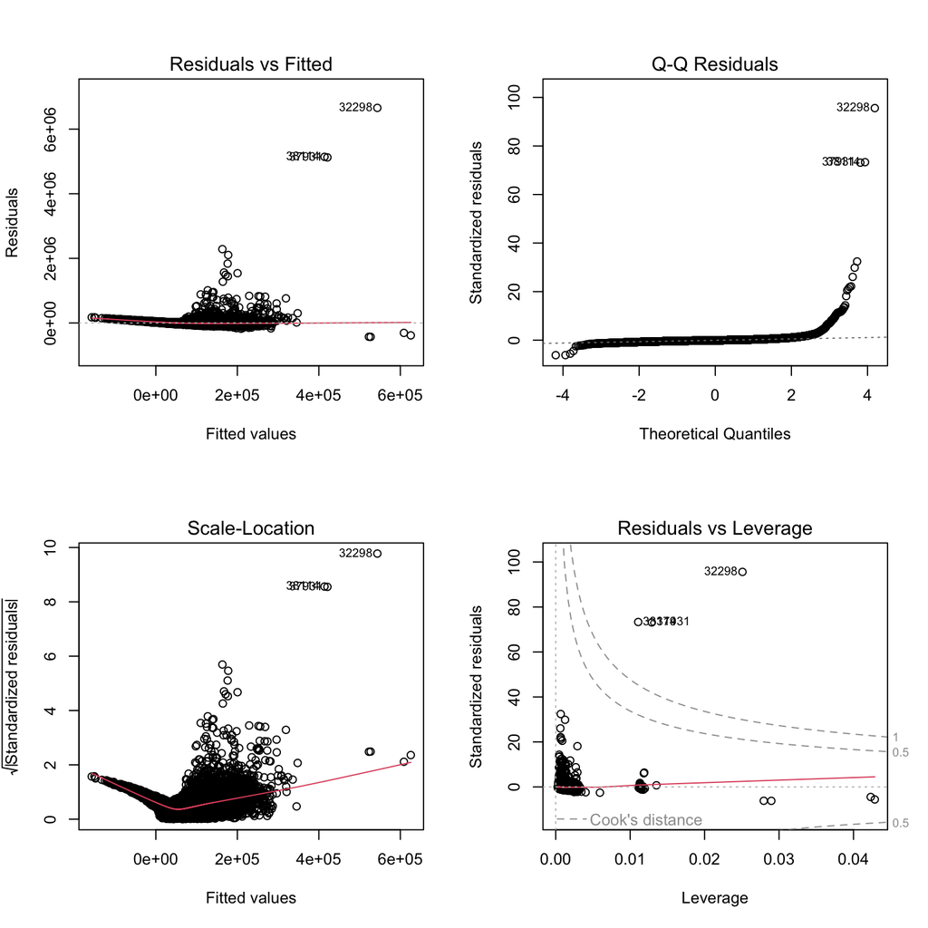

```r
# par(mfrow = c(2,2)) divides the plotting window into a 2×2 grid.
# The next 4 plots will fill each panel in order.
par(mfrow = c(2, 2))
plot(lm_model)
```

```r
# VIF = Variance Inflation Factor — measures multicollinearity.
# A VIF > 10 is a sign of serious multicollinearity.
# When two predictors are highly correlated, the model can't reliably
# estimate their individual effects.

vif(lm_model)
```

```
##                                     GVIF Df GVIF^(1/(2*Df))
## person_age                     14.139611  1        3.760267
## person_gender                   1.000632  1        1.000316
## person_education                1.068411  4        1.008306
## person_emp_exp                 11.361203  1        3.370638
## person_home_ownership           1.218673  3        1.033510
## loan_amnt                       1.802038  1        1.342400
## loan_intent                     1.059887  5        1.005833
## loan_int_rate                   1.160075  1        1.077068
## loan_percent_income             2.013628  1        1.419024
## cb_person_cred_hist_length      3.798624  1        1.949006
## credit_score                    1.137268  1        1.066428
## previous_loan_defaults_on_file  1.492377  1        1.221629
## loan_status                     1.876049  1        1.369689
```

> **🔍 Findings:**  
> - `person_age` (GVIF ≈ 14.1) and `person_emp_exp` (GVIF ≈ 11.4) are highly  
> correlated — the model struggles to separate their effects.  
> - The Q-Q plot shows non-normal residuals — a consequence of skewed income.  
> - **Solution**: log-transform the target variable.

## 6 · Transformations

### 6.1 Apply Log Transform

> **📘 Why log-transform?**  
> `log()` compresses large values and expands small ones, turning a right-skewed  
> distribution into something closer to a normal distribution.  
> This satisfies regression’s normality assumption and often dramatically improves R².

> **Trade-off**: predictions will be on the *log scale*. You must `exp()` them  
> back to the original scale to interpret results in actual dollars.

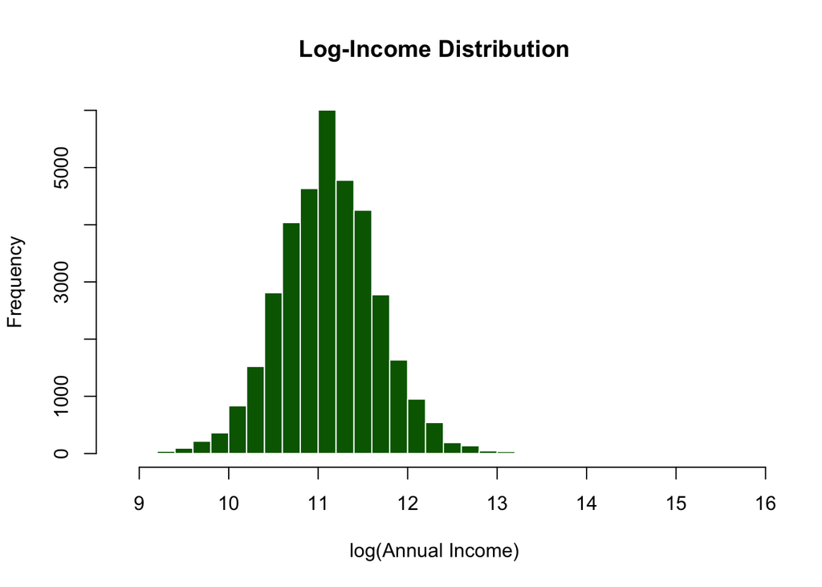

```r
# Add a new column log_income to both train and test.
# log() in R is the natural logarithm (base e).
train$log_income <- log(train$person_income)
test$log_income  <- log(test$person_income)

# Quick check — the distribution should now look more symmetric
hist(train$log_income,
     breaks = 30,
     main   = "Log-Income Distribution",
     xlab   = "log(Annual Income)",
     col    = "darkgreen",
     border = "white")
```

### 6.2 Refit with Log Income

```r
# Formula:  log_income ~ . - person_income
# The minus sign ( - person_income ) REMOVES person_income from the predictors.
# We exclude it because log_income is derived from it — including both would
# be circular (and perfectly correlated).

lm_model_log <- lm(log_income ~ . - person_income, data = train)

summary(lm_model_log)
```

```
##
## Call:
## lm(formula = log_income ~ . - person_income, data = train)
##
## Residuals:
##     Min      1Q  Median      3Q     Max
## -1.7414 -0.1213  0.0044  0.1203  3.6496
##
## Coefficients:
##                                     Estimate Std. Error  t value Pr(>|t|)
## (Intercept)                        1.110e+01  2.807e-02  395.413  < 2e-16 ***
## person_age                         6.400e-03  8.771e-04    7.296 3.02e-13 ***
## person_gendermale                  2.085e-04  2.854e-03    0.073  0.94176
## person_educationBachelor           8.031e-03  3.802e-03    2.112  0.03467 *
## person_educationDoctorate          6.584e-03  1.251e-02    0.526  0.59860
## person_educationHigh School       -1.814e-03  3.892e-03   -0.466  0.64118
## person_educationMaster             5.803e-03  4.582e-03    1.267  0.20534
## person_emp_exp                    -1.342e-03  7.850e-04   -1.710  0.08733 .
## person_home_ownershipOTHER         1.598e-02  2.818e-02    0.567  0.57073
## person_home_ownershipOWN          -1.071e-01  6.190e-03  -17.297  < 2e-16 ***
## person_home_ownershipRENT         -1.021e-01  3.201e-03  -31.911  < 2e-16 ***
## loan_amnt                          8.291e-05  3.011e-07  275.302  < 2e-16 ***
## loan_intentEDUCATION              -1.634e-03  4.782e-03   -0.342  0.73253
## loan_intentHOMEIMPROVEMENT         1.547e-02  5.662e-03    2.732  0.00631 **
## loan_intentMEDICAL                -2.081e-02  4.845e-03   -4.296 1.75e-05 ***
## loan_intentPERSONAL                2.892e-03  4.987e-03    0.580  0.56197
## loan_intentVENTURE                 7.992e-04  4.998e-03    0.160  0.87296
## loan_int_rate                     -5.960e-03  5.142e-04  -11.591  < 2e-16 ***
## loan_percent_income               -5.717e+00  2.308e-02 -247.740  < 2e-16 ***
## cb_person_cred_hist_length        -2.184e-03  7.103e-04   -3.075  0.00211 **
## credit_score                      -1.892e-06  2.998e-05   -0.063  0.94967
## previous_loan_defaults_on_fileYes -3.364e-03  3.467e-03   -0.970  0.33184
## loan_status1                      -1.153e-02  4.678e-03   -2.465  0.01372 *
## ---
## Signif. codes:  0 '***' 0.001 '**' 0.01 '*' 0.05 '.' 0.1 ' ' 1
##
## Residual standard error: 0.2692 on 35978 degrees of freedom
## Multiple R-squared:  0.7666, Adjusted R-squared:  0.7664
## F-statistic:  5370 on 22 and 35978 DF,  p-value: < 2.2e-16
```

> **🔍 R² jumped from 0.29 → 0.77!**  
> The log transformation fixed the skewness and the model now explains  
> ~77% of income variance. This is a *huge* improvement from a simple fix.

### 6.3 Check Assumptions Again

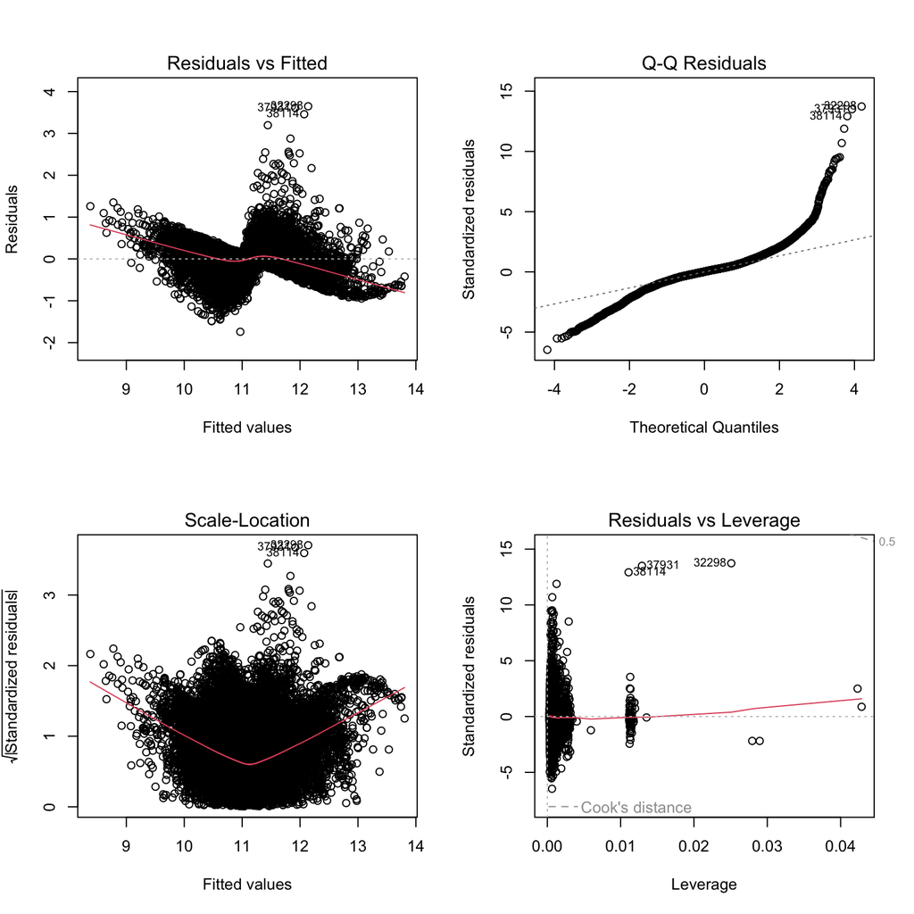

```r
par(mfrow = c(2, 2))
plot(lm_model_log)
```

```r
vif(lm_model_log)
```

```
##                                     GVIF Df GVIF^(1/(2*Df))
## person_age                     14.139611  1        3.760267
## person_gender                   1.000632  1        1.000316
## person_education                1.068411  4        1.008306
## person_emp_exp                 11.361203  1        3.370638
## person_home_ownership           1.218673  3        1.033510
## loan_amnt                       1.802038  1        1.342400
## loan_intent                     1.059887  5        1.005833
## loan_int_rate                   1.160075  1        1.077068
## loan_percent_income             2.013628  1        1.419024
## cb_person_cred_hist_length      3.798624  1        1.949006
## credit_score                    1.137268  1        1.066428
## previous_loan_defaults_on_file  1.492377  1        1.221629
## loan_status                     1.876049  1        1.369689
```

## 7 · Model Evaluation

> **📘 Metrics for regression:**  
> - **RMSE** (Root Mean Squared Error): average error in original units. Penalises  
> large errors more severely because errors are squared before averaging.  
> - **MAE** (Mean Absolute Error): average of absolute errors. More intuitive —  
> “on average, our predictions are off by MAE dollars”.  
> Lower is better for both.

```r
# Step 1: Predict on the test set (data the model has never seen)
# newdata = test tells predict() to use the test data frame
pred <- predict(lm_model_log, newdata = test)

# Step 2: Back-transform from log scale to original income scale
# exp() is the inverse of log() — exp(log(x)) = x
pred_exp <- exp(pred)

# Step 3: Calculate error metrics
RMSE <- sqrt(mean((test$person_income - pred_exp)^2))
MAE  <- mean(abs(test$person_income - pred_exp))

cat("RMSE:", round(RMSE, 2), "\n")
```

```
## RMSE: 49141.56
```

```r
cat("MAE :", round(MAE,  2), "\n")
```

```
## MAE : 16591.53
```

> **🔍 Interpretation:**  
> MAE ≈ 16,591 means the model’s predictions are off by about **$16,591** on  
> average. Whether that’s acceptable depends on the business context.

## 8 · Stepwise Regression (Model Selection)

> **📘 What is stepwise regression?**  
> Stepwise regression automates variable selection. It iteratively adds or removes  
> predictors based on the **AIC** (Akaike Information Criterion) — a measure that  
> balances model fit against complexity. Lower AIC = better model.

> `direction = "both"` means the algorithm can both add and remove variables at  
> each step (also called *bidirectional elimination*).

```r
# stepAIC() is from the MASS package.
# It prints a step-by-step log as it runs — suppressed here with results='hide'
# to keep output clean. Remove that chunk option to see the full log.
step_model <- stepAIC(lm_model_log, direction = "both")
```

```r
summary(step_model)
```

```
##
## Call:
## lm(formula = log_income ~ person_age + person_education + person_emp_exp +
##     person_home_ownership + loan_amnt + loan_intent + loan_int_rate +
##     loan_percent_income + cb_person_cred_hist_length + loan_status,
##     data = train)
##
## Residuals:
##     Min      1Q  Median      3Q     Max
## -1.7425 -0.1215  0.0044  0.1201  3.6501
##
## Coefficients:
##                               Estimate Std. Error  t value Pr(>|t|)
## (Intercept)                  1.110e+01  2.045e-02  542.614  < 2e-16 ***
## person_age                   6.398e-03  8.770e-04    7.295 3.05e-13 ***
## person_educationBachelor     8.090e-03  3.789e-03    2.135  0.03277 *
## person_educationDoctorate    6.758e-03  1.247e-02    0.542  0.58795
## person_educationHigh School -1.854e-03  3.881e-03   -0.478  0.63295
## person_educationMaster       5.903e-03  4.546e-03    1.298  0.19414
## person_emp_exp              -1.330e-03  7.835e-04   -1.698  0.08953 .
## person_home_ownershipOTHER   1.607e-02  2.818e-02    0.570  0.56852
## person_home_ownershipOWN    -1.071e-01  6.190e-03  -17.301  < 2e-16 ***
## person_home_ownershipRENT   -1.021e-01  3.201e-03  -31.912  < 2e-16 ***
## loan_amnt                    8.291e-05  3.011e-07  275.332  < 2e-16 ***
## loan_intentEDUCATION        -1.638e-03  4.781e-03   -0.343  0.73189
## loan_intentHOMEIMPROVEMENT   1.547e-02  5.662e-03    2.733  0.00628 **
## loan_intentMEDICAL          -2.082e-02  4.845e-03   -4.297 1.74e-05 ***
## loan_intentPERSONAL          2.919e-03  4.987e-03    0.585  0.55834
## loan_intentVENTURE           7.713e-04  4.997e-03    0.154  0.87734
## loan_int_rate               -5.961e-03  5.142e-04  -11.593  < 2e-16 ***
## loan_percent_income         -5.717e+00  2.307e-02 -247.766  < 2e-16 ***
## cb_person_cred_hist_length  -2.187e-03  7.102e-04   -3.080  0.00207 **
## loan_status1                -9.316e-03  4.083e-03   -2.282  0.02251 *
## ---
## Signif. codes:  0 '***' 0.001 '**' 0.01 '*' 0.05 '.' 0.1 ' ' 1
##
## Residual standard error: 0.2692 on 35981 degrees of freedom
## Multiple R-squared:  0.7666, Adjusted R-squared:  0.7664
## F-statistic:  6219 on 19 and 35981 DF,  p-value: < 2.2e-16
```

> **🔍 Result:**  
> Stepwise removed `credit_score`, `person_gender`, and `previous_loan_defaults_on_file`  
> without changing R². These variables were not adding meaningful predictive power.  
> The simpler model is preferred — fewer variables = easier to interpret and deploy.

## 9 · Classification Model — Predicting Loan Default

> **📘 What is logistic regression?**  
> Despite the name, logistic regression is a *classification* algorithm.  
> Instead of predicting a continuous number, it predicts the **probability** that  
> an observation belongs to a class (here: probability of loan default).

> We use `glm()` (Generalised Linear Model) with `family = "binomial"` — this  
> tells R we are modelling a binary outcome (0 or 1).

### 9.1 Fit the Logistic Model

```r
# Target: loan_status (0 = no default, 1 = default)
# We exclude person_income (raw) because we already have log_income.
# family = "binomial" activates the logistic regression link function.

log_model <- glm(loan_status ~ . - person_income,
                 data   = train,
                 family = "binomial")

summary(log_model)
```

```
##
## Call:
## glm(formula = loan_status ~ . - person_income, family = "binomial",
##     data = train)
##
## Coefficients:
##                                     Estimate Std. Error z value Pr(>|z|)
## (Intercept)                        9.856e+00  9.794e-01  10.063  < 2e-16 ***
## person_age                         2.536e-02  1.229e-02   2.063   0.0391 *
## person_gendermale                  4.233e-02  3.980e-02   1.064   0.2875
## person_educationBachelor           7.489e-03  5.289e-02   0.142   0.8874
## person_educationDoctorate          1.556e-02  1.668e-01   0.093   0.9257
## person_educationHigh School        4.044e-02  5.529e-02   0.731   0.4646
## person_educationMaster             4.137e-02  6.337e-02   0.653   0.5139
## person_emp_exp                    -1.834e-02  1.089e-02  -1.683   0.0923 .
## person_home_ownershipOTHER         4.514e-01  3.693e-01   1.222   0.2216
## person_home_ownershipOWN          -1.563e+00  1.162e-01 -13.448  < 2e-16 ***
## person_home_ownershipRENT          6.765e-01  4.558e-02  14.842  < 2e-16 ***
## loan_amnt                         -1.765e-05  7.928e-06  -2.226   0.0260 *
## loan_intentEDUCATION              -9.245e-01  6.580e-02 -14.051  < 2e-16 ***
## loan_intentHOMEIMPROVEMENT        -5.998e-02  7.463e-02  -0.804   0.4215
## loan_intentMEDICAL                -3.260e-01  6.365e-02  -5.122 3.02e-07 ***
## loan_intentPERSONAL               -7.661e-01  6.737e-02 -11.371  < 2e-16 ***
## loan_intentVENTURE                -1.237e+00  7.163e-02 -17.262  < 2e-16 ***
## loan_int_rate                      3.251e-01  7.384e-03  44.023  < 2e-16 ***
## loan_percent_income                1.051e+01  5.336e-01  19.698  < 2e-16 ***
## cb_person_cred_hist_length        -8.395e-03  1.034e-02  -0.812   0.4168
## credit_score                      -8.833e-03  4.623e-04 -19.107  < 2e-16 ***
## previous_loan_defaults_on_fileYes -2.030e+01  1.144e+02  -0.177   0.8591
## log_income                        -9.159e-01  8.079e-02 -11.336  < 2e-16 ***
## ---
## Signif. codes:  0 '***' 0.001 '**' 0.01 '*' 0.05 '.' 0.1 ' ' 1
##
## (Dispersion parameter for binomial family taken to be 1)
##
##     Null deviance: 38094  on 36000  degrees of freedom
## Residual deviance: 15754  on 35978  degrees of freedom
## AIC: 15800
##
## Number of Fisher Scoring iterations: 19
```

> **📘 Reading the logistic regression summary:**  
> - Coefficients are on the *log-odds* scale (not directly interpretable as probabilities).  
> - `exp(coef(log_model))` converts them to **odds ratios** — more interpretable.  
> - **AIC**: like in stepwise — lower is better. Use to compare models.  
> - **Null vs Residual deviance**: a large drop (null − residual) means the predictors  
> are explaining a lot of variation in the outcome.

### 9.2 Predictions & Confusion Matrix

> **📘 The threshold (0.5):**  
> `predict(..., type = "response")` returns probabilities between 0 and 1.  
> We need to convert these to class labels using a threshold.  
> `ifelse(prob > 0.5, 1, 0)` means: “predict default if probability > 50%”.  
> You can adjust this threshold to trade off sensitivity vs. specificity.

```r
# type = "response" returns probabilities (not log-odds)
prob       <- predict(log_model, newdata = test, type = "response")

# Convert probabilities to binary predictions using 0.5 threshold
pred_class <- ifelse(prob > 0.5, 1, 0)

# confusionMatrix() from caret compares predictions vs. true labels
confusionMatrix(as.factor(pred_class), test$loan_status)
```

```
## Confusion Matrix and Statistics
##
##           Reference
## Prediction    0    1
##          0 6546  484
##          1  435 1534
##
##                Accuracy : 0.8979
##                  95% CI : (0.8914, 0.9041)
##     No Information Rate : 0.7758
##     P-Value [Acc > NIR] : <2e-16
##
##                   Kappa : 0.7039
##
##  Mcnemar's Test P-Value : 0.1133
##
##             Sensitivity : 0.9377
##             Specificity : 0.7602
##          Pos Pred Value : 0.9312
##          Neg Pred Value : 0.7791
##              Prevalence : 0.7758
##          Detection Rate : 0.7274
##    Detection Prevalence : 0.7812
##       Balanced Accuracy : 0.8489
##
##        'Positive' Class : 0
##
```

> **📘 Confusion Matrix explained:**

> |  | Predicted: No Default | Predicted: Default |
> | --- | --- | --- |
> | **Actual: No Default** | True Negative (TN) | False Positive (FP) |
> | **Actual: Default** | False Negative (FN) | True Positive (TP) |

> **High sensitivity** is often more important in lending — missing a default is  
> more costly than wrongly flagging a good borrower.

### 9.3 ROC Curve

> **📘 What is the ROC Curve?**  
> The **Receiver Operating Characteristic** curve plots sensitivity (true positive rate)  
> vs. 1 − specificity (false positive rate) at every possible threshold.

> A model that randomly guesses falls on the diagonal. A perfect model hits the  
> top-left corner. The **AUC** (Area Under the Curve) summarises performance:  
> - AUC = 0.5: no better than random  
> - AUC = 1.0: perfect  
> - AUC > 0.9: excellent

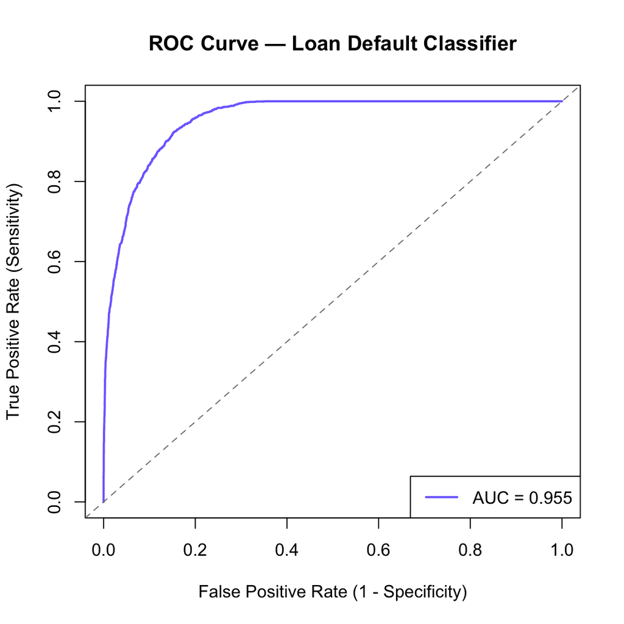

```r
# prediction() and performance() are from the ROCR package.
# They create objects that know how to plot themselves.
pred_obj <- prediction(prob, test$loan_status)
perf     <- performance(pred_obj, "tpr", "fpr")

plot(perf,
     col     = "#7c6fff",
     lwd     = 2,
     main    = "ROC Curve — Loan Default Classifier",
     xlab    = "False Positive Rate (1 - Specificity)",
     ylab    = "True Positive Rate (Sensitivity)")

# Reference line: what a random classifier would look like
abline(a = 0, b = 1, col = "grey50", lty = 2)

# Calculate and display AUC
auc <- performance(pred_obj, "auc")@y.values[[1]]
legend("bottomright",
       legend = paste0("AUC = ", round(auc, 3)),
       col    = "#7c6fff", lty = 1, lwd = 2)
```

## 10 · Feature Engineering

> **📘 What is feature engineering?**  
> Feature engineering means creating *new* columns (features) from existing ones  
> that might be more informative for a model. Good features capture domain  
> knowledge — for example, “income relative to experience” captures *productivity*  
> in a way that raw income or experience alone do not.

```r
# Feature 1: income per year of experience
# Adding 1 prevents division by zero for people with 0 experience
data$income_per_experience <- data$person_income / (data$person_emp_exp + 1)

# Feature 2: loan amount as a fraction of credit score
# Higher ratio = potentially riskier loan relative to creditworthiness
data$loan_to_credit_ratio  <- data$loan_amnt / data$credit_score

# Inspect the new features
summary(data[, c("income_per_experience", "loan_to_credit_ratio")])
```

```
##  income_per_experience loan_to_credit_ratio
##  Min.   :   258.1      Min.   : 0.6983
##  1st Qu.:  7562.0      1st Qu.: 7.7295
##  Median : 15463.4      Median :12.8824
##  Mean   : 27106.5      Mean   :15.2443
##  3rd Qu.: 35923.8      3rd Qu.:20.2703
##  Max.   :577186.0      Max.   :74.4681
```

> **💡 Next steps:**  
> After engineering features, you would re-run the train/test split  
> (including the new columns) and refit your models to see if performance improves.

## 11 · Summary & Key Takeaways

Model Comparison

[output not shown]

> **🎓 R Concepts Covered:**  
> `<-` assignment · `library()` · `read.csv()` · `head()` · `summary()` ·  
> `as.factor()` · `%>%` pipe · `dplyr::select()` · `cor()` · `corrplot()` ·  
> `hist()` · `set.seed()` · `createDataPartition()` · `lm()` · `glm()` ·  
> `par(mfrow)` · `plot(model)` · `vif()` · `log()` · `exp()` · `predict()` ·  
> `stepAIC()` · `ifelse()` · `confusionMatrix()` · `prediction()` · `performance()`

*Knit this document to HTML with the **Knit** button in RStudio to see the full formatted report.*